# Advanced Bioinformatics 2023 assessment

**TASK 6**

#Plot data points from previous question using ggplot

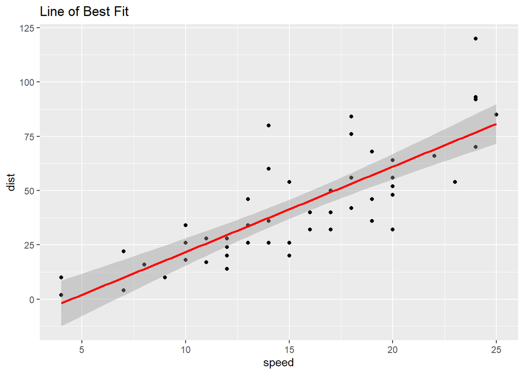

```r
library(ggplot2)
ggplot(data = cars, aes(x = speed, y = dist)) +
  geom_point() +
  geom_smooth(method = "lm", colour = "red") +
  labs(title = "Line of Best Fit")
```

**TASK 7**

#Assuming that reaction time equals (dist/speed^2), new variables with similar units are assigned.

```r
data(cars)
#Assign new variable 'speed_square' in mph)
speed_square = (cars$speed)^2

#Convert distance from ft to miles
dist_miles = cars$dist *0.000189394

#Use 'lm' function to get the line equation:
lm(dist_miles ~ speed_square, data = cars)
```

```
##
## Call:
## lm(formula = dist_miles ~ speed_square, data = cars)
##
## Coefficients:
##  (Intercept)  speed_square
##    1.678e-03     2.443e-05
```

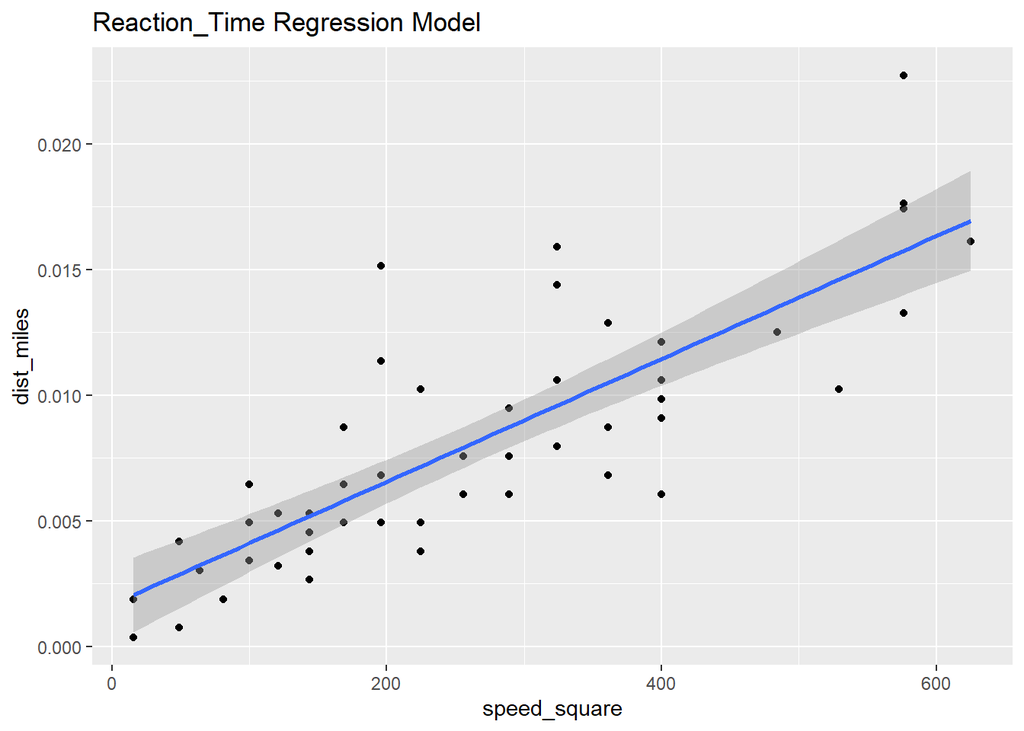

```r
##We get a slope of 2.443e-05  which is equal to 0.088s (REACTION TIME)
#Plot the results using ggplot
library(ggplot2)
ggplot(data = cars, aes(x = speed_square, y = dist_miles)) +
  geom_point() +
  geom_smooth(method = "lm") +
  labs (title = "Reaction_Time Regression Model")
```

#The results are reasonable in this context of analysis since both plots are concordant. However they are not reasonable in real world situations because the thinking distance, mass of the vehicle, work done, status of the ground and external factors such as drinking, fatigue, driver experience and distractions were not taken into account. In addition, the actual average drivers’ reaction time ranges from 0.75 to 1.5s, so 0.088s is a drastic overestimation of how fast drivers respond to hazard.